# Mindboggle `mbhard` — landmark detection, matching and physical-space display

Generated 2026-09-14 16:38 by `scripts/landmarks_mbhard_report.py`. All coordinates are physical LPS millimetres computed through `syntx.landmarks.spatial`; images are never reoriented — display orientation and keypoint overlays are derived from the direction cosine matrices. Preprocessing: ANTsTorch N4 + non-local-means denoising on MPS, then foreground 2–98% normalisation. Detection: `detect_sift3d`, 10 scales from 1 to 8 mm, relative threshold 0.002, NMS radius 3 mm, at most 2000 keypoints per image; foreground-masked; 512-D physical-space descriptors. Matching: Lowe ratio 0.95 + mutual nearest neighbour → RANSAC affine, inlier threshold 8.0 mm. Inter-subject pairs are related non-rigidly, so the affine is a consensus filter; agreement of DKT31+aseg whole-brain labels at matched endpoints (chance level shown) is the accuracy proxy.

## Example 1 — native pair

Fixed and moving are stored in different native frames (LAS vs RPS arrays, 1.0 vs 1.2 mm x-spacing).

### Global rotation search

Hypotheses fixed→moving: identity plus the four principal-axis alignments of the two landmark clouds. Each is refined iteratively (descriptors rebuilt in the current frame → match → rigid RANSAC → rotation), coarse-to-fine over the strongest 25% → 50% → 100% of keypoints; the converged hypothesis with most rigid inliers wins.

| hypothesis | start (deg) | converged (deg) | iterations | rigid inliers per iteration (@ keypoint fraction) |
| --- | --- | --- | --- | --- |
| identity | 0.0 | 2.3 | 4 | 34@25% → 59@50% → 119@100% → 119@100% |
| pca0 | 175.6 | 122.5 | 5 | 0@25% → 2@50% → 5@100% → 4@100% → 3@100% |
| pca1 | 5.6 | 2.3 | 4 | 31@25% → 59@50% → 119@100% → 119@100% |
| pca2 | 179.9 | 155.7 | 6 | 3@25% → 3@50% → 4@100% → 8@100% → 6@100% → 4@100% |
| pca3 | 176.5 | 176.5 | 3 | 0@25% → 2@50% → 3@100% |

### Geometry

| image | shape | spacing (mm) | origin (mm) | array axes point to | centre of mass (mm) |
| --- | --- | --- | --- | --- | --- |
| fixed | (192, 256, 256) | [1.0, 1.0, 1.0] | [-95.5, 102.0, -130.7] | LAS | [-0.0, -3.9, 19.4] |
| moving | (170, 256, 256) | [1.2, 1.0, 1.0] | [202.8, -0.0, 0.0] | RPS | [99.6, 132.0, 131.6] |

### Timings

| step | seconds |
| --- | --- |
| preprocess fixed | 1.4 |
| preprocess moving | 0.8 |
| sift3d + rotation search (both) | 16.6 |
| match + RANSAC | 0.0 |

### Results

| quantity | fixed | moving |
| --- | --- | --- |
| SIFT3D keypoints | 1536 | 1280 |
| fraction of keypoints inside brain foreground | 1.000 | 1.000 |
| fraction of keypoints carrying a whole-brain label | 0.92 | 0.94 |

| quantity | value |
| --- | --- |
| ratio-test + mutual matches | 287 |
| RANSAC affine inliers | 182 |
| label agreement — random pairs (chance) | 0.074 |
| label agreement — ratio+mutual matches | 0.648 |
| label agreement — RANSAC inliers | 0.747 |
| median / max affine residual on inliers (mm) | 3.46 / 7.97 |
| centre-of-mass prediction error of recovered affine (mm) | 4.6 |
| singular values of recovered linear part | [1.0199999809265137, 0.9819999933242798, 0.9520000219345093] |
| rotation angle of recovered linear part (deg) | 2.2 |

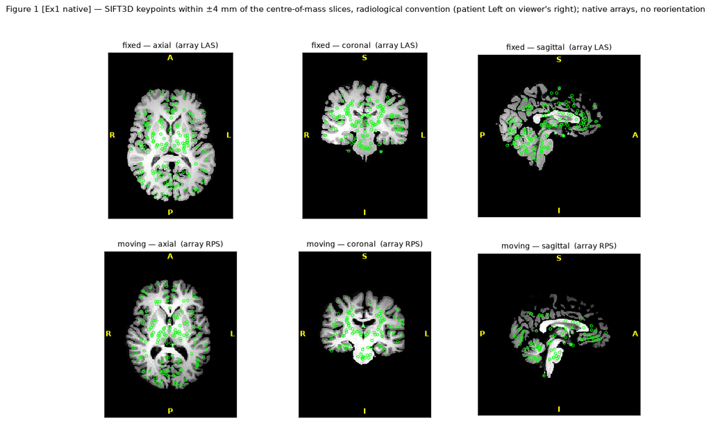

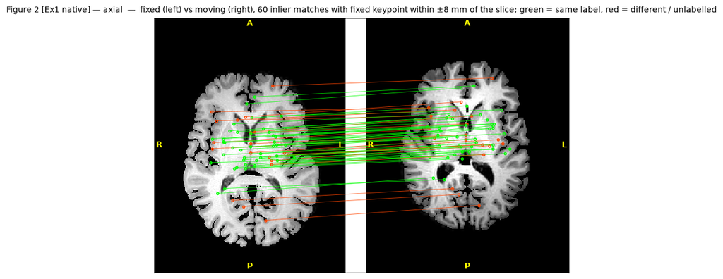

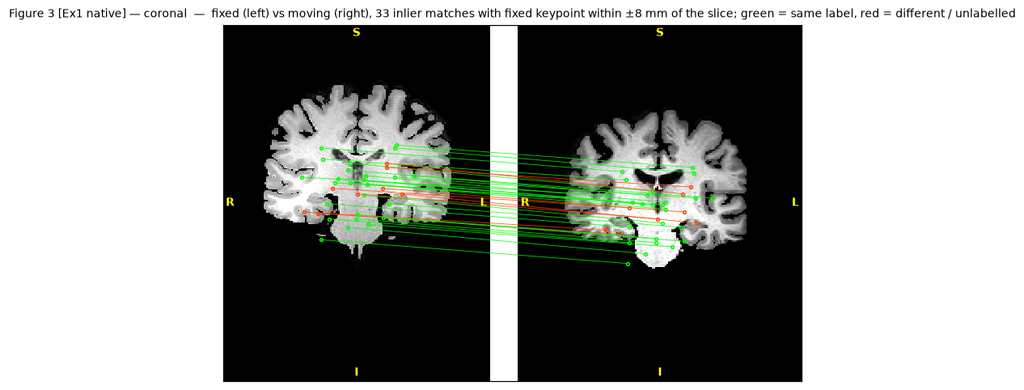

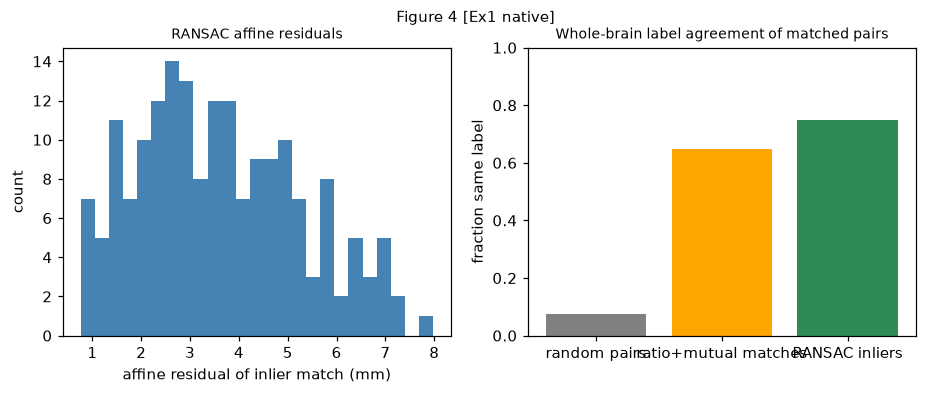

### Matching variants

| descriptor | keypoints f/m | matches | RANSAC inliers | inlier label agreement (chance) | median resid (mm) | COM err (mm) | singular values | rotation (deg) |
| --- | --- | --- | --- | --- | --- | --- | --- | --- |
| rotation search (shown above) | 1536/1280 | 287 | 182 | 0.75 (0.07) | 3.46 | 4.6 | [1.0199999809265137, 0.9819999933242798, 0.9520000219345093] | 2.2 |
| plain scanner-axis-aligned | 1536/1280 | 287 | 184 | 0.75 (0.07) | 3.46 | 4.4 | [1.0130000114440918, 0.9779999852180481, 0.9520000219345093] | 2.9 |
| plain rotation-invariant (structure-tensor frame) | 1536/1280 | 144 | 41 | 0.80 (0.07) | 2.75 | 4.6 | [1.0429999828338623, 0.9810000061988831, 0.9139999747276306] | 3.4 |

## Example 2 — fixed rotated +30°, moving rotated −30° about the superior axis

Both volumes (and their label maps) were resampled onto their own grids after a rigid rotation about the z axis through each centre of mass, so the two heads now differ by ≈60° of yaw in physical space. The axis-aligned SIFT3D descriptor tolerates roughly 30° of relative rotation, so plain matching fails here; `match_sift3d_with_rotation_search` seeds a global fixed→moving rotation from the principal axes of the two landmark clouds and refines it iteratively (descriptors rebuilt in the current frame → match → rigid RANSAC → rotation; coarse-to-fine over keypoint strength). The figures use that pipeline; the plain variants are tabulated for comparison. The recovered affine is also compared with the one predicted from Example 1 and the known rotations (M₂ ≈ T<sub>m</sub>⁻¹ · M₁ · T<sub>f</sub>).

**Descriptor / matching:** axis-aligned in a globally estimated frame (PCA-seeded iterative search, winner 'pca3', rotation 61.4°).

### Global rotation search

Hypotheses fixed→moving: identity plus the four principal-axis alignments of the two landmark clouds. Each is refined iteratively (descriptors rebuilt in the current frame → match → rigid RANSAC → rotation), coarse-to-fine over the strongest 25% → 50% → 100% of keypoints; the converged hypothesis with most rigid inliers wins.

| hypothesis | start (deg) | converged (deg) | iterations | rigid inliers per iteration (@ keypoint fraction) |
| --- | --- | --- | --- | --- |
| identity | 0.0 | 162.7 | 5 | 3@25% → 3@50% → 4@100% → 4@100% → 3@100% |
| pca0 | 124.2 | 124.2 | 3 | 3@25% → 3@50% → 3@100% |
| pca1 | 169.2 | 169.2 | 3 | 3@25% → 3@50% → 3@100% |
| pca2 | 153.8 | 98.9 | 6 | 3@25% → 3@50% → 4@100% → 4@100% → 7@100% → 8@100% |
| pca3 | 63.8 | 61.4 | 5 | 30@25% → 54@50% → 117@100% → 115@100% → 109@100% |

### Geometry

| image | shape | spacing (mm) | origin (mm) | array axes point to | centre of mass (mm) |
| --- | --- | --- | --- | --- | --- |
| fixed | (192, 256, 256) | [1.0, 1.0, 1.0] | [-95.5, 102.0, -130.7] | LAS | [-0.0, -3.9, 19.4] |
| moving | (170, 256, 256) | [1.2, 1.0, 1.0] | [202.8, -0.0, 0.0] | RPS | [99.6, 132.0, 131.6] |

### Timings

| step | seconds |
| --- | --- |
| preprocess fixed | 1.1 |
| preprocess moving | 0.8 |
| sift3d + rotation search (both) | 15.7 |
| match + RANSAC | 0.0 |

### Results

| quantity | fixed | moving |
| --- | --- | --- |
| SIFT3D keypoints | 1502 | 1221 |
| fraction of keypoints inside brain foreground | 1.000 | 1.000 |
| fraction of keypoints carrying a whole-brain label | 0.82 | 0.86 |

| quantity | value |
| --- | --- |
| ratio-test + mutual matches | 267 |
| RANSAC affine inliers | 182 |
| label agreement — random pairs (chance) | 0.060 |
| label agreement — ratio+mutual matches | 0.596 |
| label agreement — RANSAC inliers | 0.698 |
| median / max affine residual on inliers (mm) | 3.77 / 7.93 |
| centre-of-mass prediction error of recovered affine (mm) | 5.2 |
| singular values of recovered linear part | [1.0609999895095825, 1.0010000467300415, 0.9629999995231628] |
| rotation angle of recovered linear part (deg) | 61.0 |

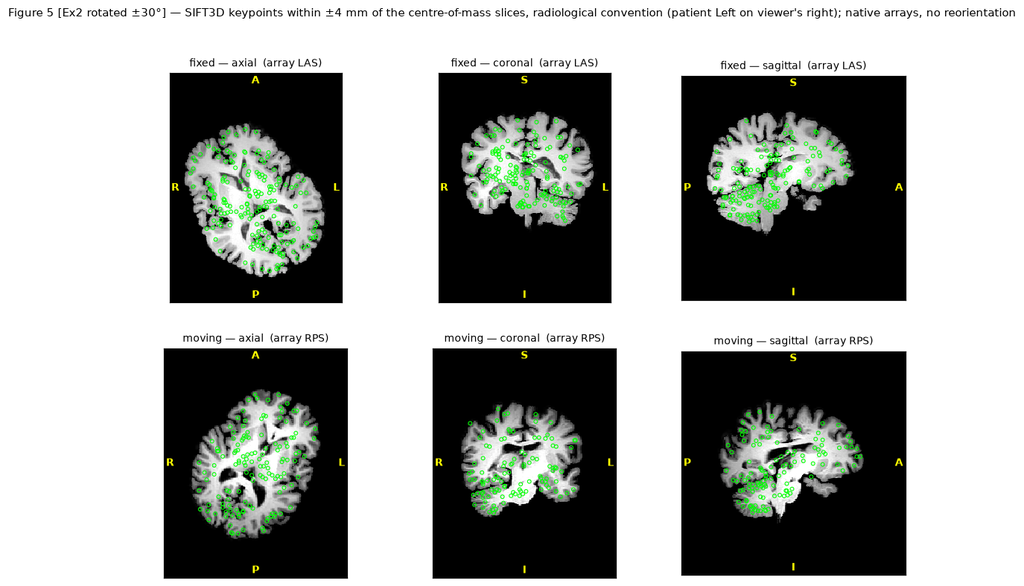

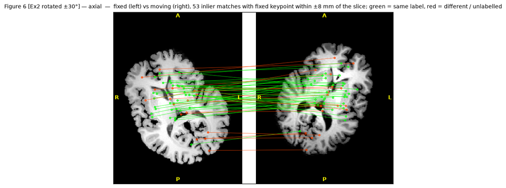

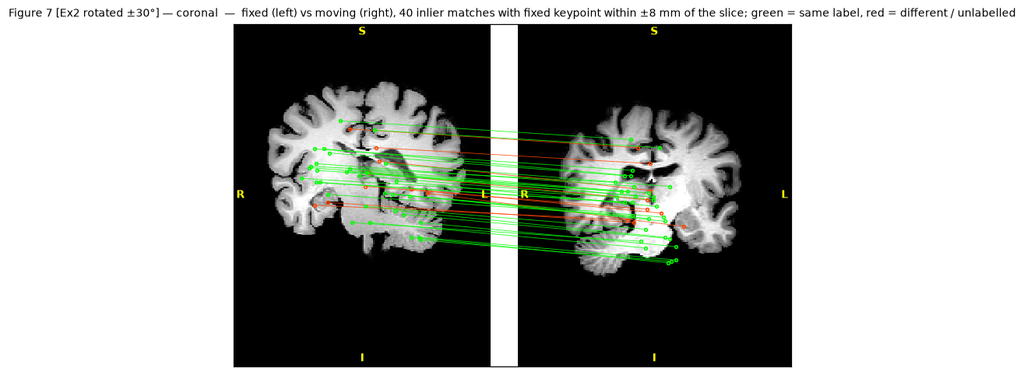

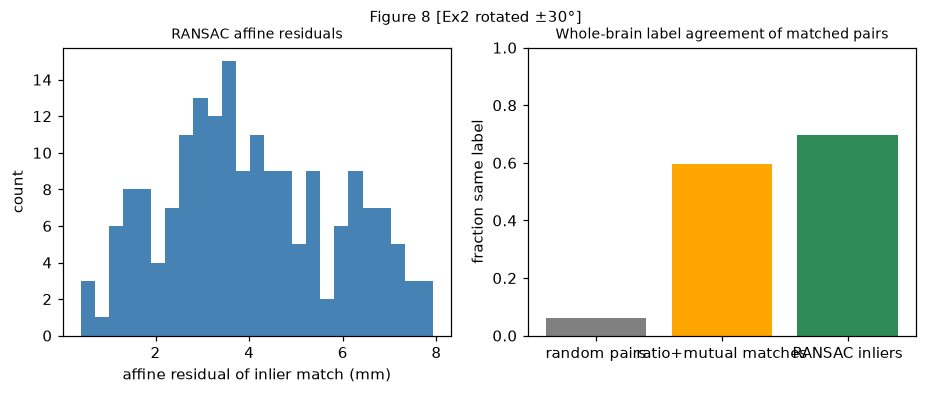

### Matching variants

| descriptor | keypoints f/m | matches | RANSAC inliers | inlier label agreement (chance) | median resid (mm) | COM err (mm) | singular values | rotation (deg) |
| --- | --- | --- | --- | --- | --- | --- | --- | --- |
| rotation search (shown above) | 1502/1221 | 267 | 182 | 0.70 (0.06) | 3.77 | 5.2 | [1.0609999895095825, 1.0010000467300415, 0.9629999995231628] | 61.0 |
| plain scanner-axis-aligned | 1502/1221 | 113 | 7 | 0.57 (0.06) | 2.67 | 20.9 | [1.6100000143051147, 1.2860000133514404, 0.800000011920929] | 51.4 |
| plain rotation-invariant (structure-tensor frame) | 1502/1221 | 160 | 44 | 0.70 (0.06) | 3.57 | 4.6 | [1.1180000305175781, 1.003000020980835, 0.9490000009536743] | 61.8 |

### Consistency between the two examples

[output not shown]